# Data 608 - Final Project

Leticia Salazar

December 11, 2022

$~$

# Polycystic Ovarian Syndrome (PCOS)

$~$

## Overview:

Polycystic ovarian syndrome (PCOS) is a reproductive hormonal imbalance condition affecting as much as 5 million women in the US alone. It’s believed that genetics and environmental factors can cause PCOS that affect their body physically and emotionally along with their metabolism, overall health and appearance in women. PCOS causes problems in ovaries making it hard for women to have a healthy menstrual cycle leading to the development of cysts and infertility. Although very common in women of reproductive age, PCOS may begin shortly after puberty but can also develop during the later teenage years and early adulthood.

$~$

Hormones that are involved in PCOS are:

- **Androgens:** aka “male hormones” are present in women with PCOS at higher levels than usual. Excess in androgens can cause symptoms such as acne, unwanted hair, thinning hair, and irregular periods.
- **Insulin:** allows the body to absorb glucose (blood sugar) into the cells for energy. In PCOS, the body doesn’t respond to insulin as intended therefore, elevations in blood glucose levels can be assessed. Such elevations then lead to increased production of androgen.
- **Progesterone:** vital hormone for menstruation and pregnancy; lack of progesterone contributes to irregular periods.

$~$

PCOS Symptoms:

Many of these symptoms can be attributed to other causes or go unnoticed but it is very common for PCOS to go undiagnosed for some time. Here are some symptoms that help with the diagnosis:

- **Irregular periods:** irregular or missed periods as are a result of not ovulating is a common signs of PCOS
- **Polycystic ovaries:** some may develop cysts in their ovaries but some don’t. Ovaries may be enlarged and follicles surrounding their eggs therefore failing to function regularly.
- **Excess androgen:** elevated levels of male hormones can cause excess hair and acne.

$~$

Other symptoms may include:

- **Weight gain:** many people with PCOS will have weight gain or obesity that is difficult to manage.
- **Fatigue:** increase in fatigue or low energy is also common
- **Unwanted hair growth:** due to excess androgen, areas such as face, arms, back, chest, hand, toes and abdomen may have excess hair growth.
- **Thinning hair on the head:** hair loss may increase in middle age for those with PCOS
- **Infertility:** PCOS is a leading cause for infertility but not everyone is the same.
- **Acne:** due to hormonal changes, acne can be arise and make skin oilier than usual and cause breakout in the face, chest and upper back.
- **Darkening of skin:** areas such as under arms, breasts or back of your neck may get dark, patchy or thicken
- **Mood changes:** mood swings, depression and anxiety can increase
- **Pelvic pain:** pain may occur with periods along with heavy bleeding or without bleeding
- **Headaches:** can occur due to hormonal changes
- **Sleep problems:** most people often suffer with problem such as insomnia or poor sleep. These arise due to many factors but a common one is having sleep apnea (sleep disorder). Even when you fall asleep you wake up as if you have not slept at all or have trouble falling asleep.
- **Depression:** can arise due to symptoms that can alter your appearance and have a negative impact on your emotions.
- **It’s good to note that not everyone who is diagnosed with PCOS experiences all of these symptoms and should always consult with a their PCP or OBGYN to get an accurate diagnosis.** *

$~$

### Relevancy:

Being diagnosed almost 2 years ago with PCOS I was intrigued to learn more and explore the data that was available. Although not much data was easily accessible this is a start to explore differences or similarities women share with their physical aspect and blood work. It’s also important to be aware of symptoms experienced by PCOS because it’s such symptoms that can always be misinterpreted as “too much stress” or “just lose weight” by doctors. After advocating for myself with multiple doctors over the span of 6 years I saw the true value in listening to your body and sharing my experience with others.

$~$

### Load Libraries:

These are the libraries used to explore, prepare and visualize the data

```r
library(tidyverse)
library(dplyr)
library(corrplot)
library(DataExplorer)
library(hrbrthemes)
library(ggplot2)
library(plotly)
```

### Load data:

$~$

#### Description:

Below is a short description of the variables of interest in the data sets:

- The data sets I will be using are from [Kaggle](https://www.kaggle.com/datasets/prasoonkottarathil/polycystic-ovary-syndrome-pcos) collected from 10 different hospital across Kerala, India:

Things to consider and understand the data set:

- Units used are feet to cm
- For Yes | No questions
  - Yes = 1
  - No = 0
- Blood Groups:
  - A+ = 11
  - A- = 12
  - B+ = 13
  - B- = 14
  - O+ =15
  - O- = 16
  - AB+ = 17
  - AB- = 18
- RBS means Random glucose test
- Beta-HCG cases are mentioned as Case I and II.

$~$

I have included the original data sets in my [GitHub](https://github.com/letisalba/Data_608/tree/master/Final%20Project/csv) account and read from this location.

Lets view the `pcos` data:

```
##   Sl..No Patient.File.No. PCOS..Y.N. I...beta.HCG.mIU.mL.
## 1      1            10001          0                 1.99
## 2      2            10002          0                60.80
## 3      3            10003          1               494.08
## 4      4            10004          0                 1.99
##   II....beta.HCG.mIU.mL. AMH.ng.mL.
## 1                   1.99       2.07
## 2                   1.99       1.53
## 3                 494.08       6.63
## 4                   1.99       1.22
```

… And the `pcos_infertility` data:

```
##   Sl..No Patient.File.No. PCOS..Y.N. Age..yrs. Weight..Kg. Height.Cm.    BMI
## 1      1                1          0        28        44.6      152.0   19.3
## 2      2                2          0        36        65.0      161.5 #NAME?
## 3      3                3          1        33        68.8      165.0 #NAME?
## 4      4                4          0        37        65.0      148.0 #NAME?
##   Blood.Group Pulse.rate.bpm. RR..breaths.min. Hb.g.dl. Cycle.R.I.
## 1          15              78               22    10.48          2
## 2          15              74               20    11.70          2
## 3          11              72               18    11.80          2
## 4          13              72               20    12.00          2
##   Cycle.length.days. Marraige.Status..Yrs. Pregnant.Y.N. No..of.aborptions
## 1                  5                     7             0                 0
## 2                  5                    11             1                 0
## 3                  5                    10             1                 0
## 4                  5                     4             0                 0
```

[output cut: 30 more lines]

$~$

### Data Exploration:

The first data set `pcos` includes 541 observations and a total of 6 variables. The second data set `pcos_infertility` includes 541 observations and a total of 45 variables. Notice that the column names are not clear enough for readers, this will be tackled in the data preparation section.

```
## Rows: 541
## Columns: 6
## $ Sl..No                 <int> 1, 2, 3, 4, 5, 6, 7, 8, 9, 10, 11, 12, 13, 14, …
## $ Patient.File.No.       <int> 10001, 10002, 10003, 10004, 10005, 10006, 10007…
## $ PCOS..Y.N.             <int> 0, 0, 1, 0, 0, 0, 0, 0, 0, 0, 0, 0, 1, 0, 0, 0,…
## $ I...beta.HCG.mIU.mL.   <dbl> 1.99, 60.80, 494.08, 1.99, 801.45, 237.97, 1.99…
## $ II....beta.HCG.mIU.mL. <dbl> 1.99, 1.99, 494.08, 1.99, 801.45, 1.99, 1.99, 1…
## $ AMH.ng.mL.             <chr> "2.07", "1.53", "6.63", "1.22", "2.26", "6.74",…
```

```
## Rows: 541
## Columns: 45
## $ Sl..No                 <int> 1, 2, 3, 4, 5, 6, 7, 8, 9, 10, 11, 12, 13, 14, …
## $ Patient.File.No.       <int> 1, 2, 3, 4, 5, 6, 7, 8, 9, 10, 11, 12, 13, 14, …
## $ PCOS..Y.N.             <int> 0, 0, 1, 0, 0, 0, 0, 0, 0, 0, 0, 0, 1, 0, 0, 0,…
## $ Age..yrs.              <int> 28, 36, 33, 37, 25, 36, 34, 33, 32, 36, 20, 26,…
## $ Weight..Kg.            <dbl> 44.6, 65.0, 68.8, 65.0, 52.0, 74.1, 64.0, 58.5,…
## $ Height.Cm.             <dbl> 152.0, 161.5, 165.0, 148.0, 161.0, 165.0, 156.0…
## $ BMI                    <chr> "19.3", "#NAME?", "#NAME?", "#NAME?", "#NAME?",…
## $ Blood.Group            <int> 15, 15, 11, 13, 11, 15, 11, 13, 11, 15, 15, 13,…
## $ Pulse.rate.bpm.        <int> 78, 74, 72, 72, 72, 78, 72, 72, 72, 80, 80, 72,…
## $ RR..breaths.min.       <int> 22, 20, 18, 20, 18, 28, 18, 20, 18, 20, 20, 20,…
## $ Hb.g.dl.               <dbl> 10.48, 11.70, 11.80, 12.00, 10.00, 11.20, 10.90…
## $ Cycle.R.I.             <int> 2, 2, 2, 2, 2, 2, 2, 2, 2, 4, 2, 2, 4, 2, 2, 2,…
## $ Cycle.length.days.     <int> 5, 5, 5, 5, 5, 5, 5, 5, 5, 2, 5, 5, 2, 5, 5, 5,…
```

[output cut: 32 more lines]

$~$

Let’s look at the distribution of our data sets using histograms:

`pcos` data:

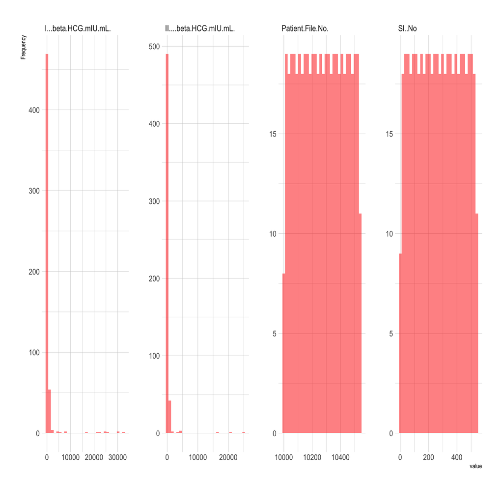

$~$

`pcos_infertility` data:

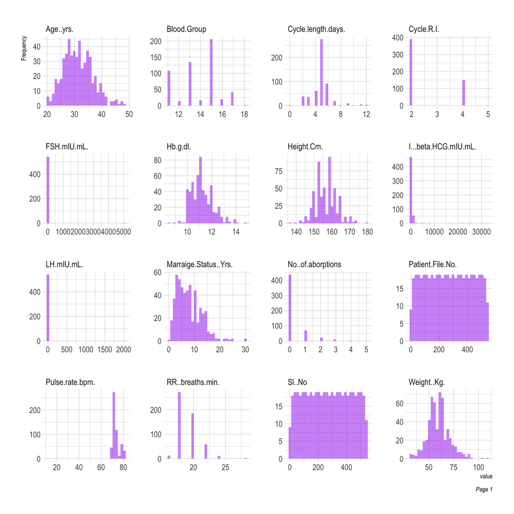

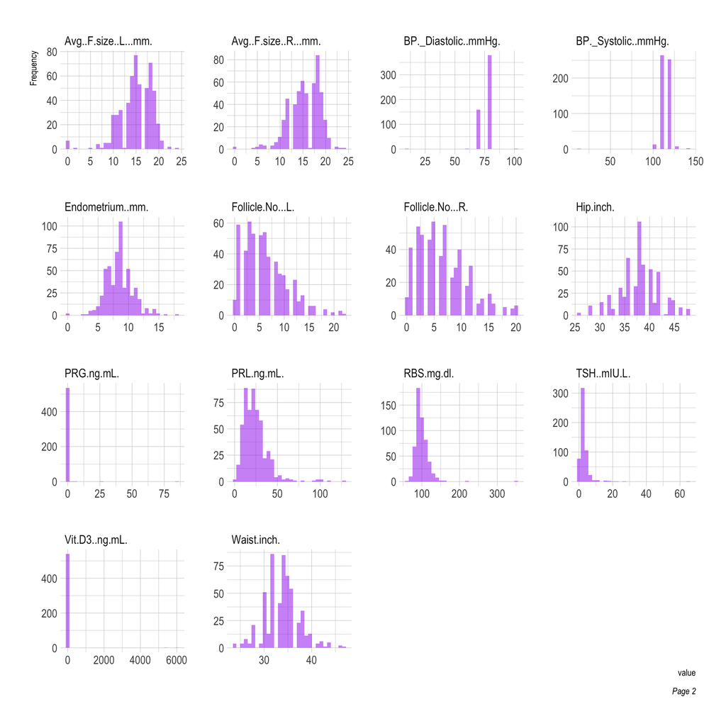

$~$

### Data Preparation:

```r
colnames(pcos)
```

```
## [1] "Sl..No"                 "Patient.File.No."       "PCOS..Y.N."
## [4] "I...beta.HCG.mIU.mL."   "II....beta.HCG.mIU.mL." "AMH.ng.mL."
```

```r
colnames(pcos_infertility)
```

```
##  [1] "Sl..No"                 "Patient.File.No."       "PCOS..Y.N."
##  [4] "Age..yrs."              "Weight..Kg."            "Height.Cm."
##  [7] "BMI"                    "Blood.Group"            "Pulse.rate.bpm."
## [10] "RR..breaths.min."       "Hb.g.dl."               "Cycle.R.I."
## [13] "Cycle.length.days."     "Marraige.Status..Yrs."  "Pregnant.Y.N."
## [16] "No..of.aborptions"      "I...beta.HCG.mIU.mL."   "II....beta.HCG.mIU.mL."
## [19] "FSH.mIU.mL."            "LH.mIU.mL."             "FSH.LH"
## [22] "Hip.inch."              "Waist.inch."            "Waist.Hip.Ratio"
## [25] "TSH..mIU.L."            "AMH.ng.mL."             "PRL.ng.mL."
## [28] "Vit.D3..ng.mL."         "PRG.ng.mL."             "RBS.mg.dl."
## [31] "Weight.gain.Y.N."       "hair.growth.Y.N."       "Skin.darkening..Y.N."
## [34] "Hair.loss.Y.N."         "Pimples.Y.N."           "Fast.food..Y.N."
## [37] "Reg.Exercise.Y.N."      "BP._Systolic..mmHg."    "BP._Diastolic..mmHg."
## [40] "Follicle.No...L."       "Follicle.No...R."       "Avg..F.size..L...mm."
## [43] "Avg..F.size..R...mm."   "Endometrium..mm."       "X"
```

As mentioned earlier, my data preparation will mainly consist of renaming columns, targeting missing values whether it is by replacing them with a mean, median or mode for `Marriage Status (Yrs)` and `Fast Food (Y/N)` or calculating the values as a whole as its the case of `BMI`, `FSH.LH` and `Waist.Hip.Ratio`. I’ll also remove columns that are duplicate or not need so that it’s easier to manage when I merge my two data sets.

$~$

Here’s the results after part 1 of the preparation process:

```r
# merge data sets
pcos_data <- merge(pcos, pcos_infertility,  by=c("Sl.No"))
head(pcos_data)
```

```
##   Sl.No PCOS Ibeta-HCG(mIU/mL) IIbeta-HCG(mIU/mL) AMH(ng/mL) Age(yrs)
## 1     1    0              1.99               1.99       2.07       28
## 2     2    0             60.80               1.99       1.53       36
## 3     3    1            494.08             494.08       6.63       33
## 4     4    0              1.99               1.99       1.22       37
## 5     5    0            801.45             801.45       2.26       25
## 6     6    0            237.97               1.99       6.74       36
##   Weight(kg) Height(cm)  BMI Blood_Group Pulse rate(bpm) RR(breaths/min)
## 1       44.6      152.0 19.3          15              78              22
## 2       65.0      161.5   NA          15              74              20
## 3       68.8      165.0   NA          11              72              18
## 4       65.0      148.0   NA          13              72              20
## 5       52.0      161.0   NA          11              72              18
## 6       74.1      165.0   NA          15              78              28
##   Hb(g/dl) Cycle(R/I) Cycle_length(days) Marriage_Status(yrs) Pregnant
```

[output cut: 41 more lines]

$~$

Checking for missing data:

```
##                Sl.No                 PCOS    Ibeta-HCG(mIU/mL)
##                    0                    0                    0
##   IIbeta-HCG(mIU/mL)           AMH(ng/mL)             Age(yrs)
##                    0                    1                    0
##           Weight(kg)           Height(cm)                  BMI
##                    0                    0                  299
##          Blood_Group      Pulse rate(bpm)      RR(breaths/min)
##                    0                    0                    0
##             Hb(g/dl)           Cycle(R/I)   Cycle_length(days)
##                    0                    0                    0
## Marriage_Status(yrs)             Pregnant      No_of_abortions
##                    1                    0                    0
##          FSH(mIU/mL)           LH(mIU/mL)               FSH-LH
##                    0                    0                  532
##              Hip(in)            Waist(in)      Waist-Hip_Ratio
##                    0                    0                  532
##          TSH (mIU/L)           PRL(ng/mL)        Vit_D3(ng/mL)
##                    0                    0                    0
##           PRG(ng/mL)           RBS(mg/dl)          Weight_gain
##                    0                    0                    0
##          hair_growth       Skin_darkening            Hair_loss
##                    0                    0                    0
##              Pimples            Fast_food         Reg_Exercise
##                    0                    1                    0
##    BP_Systolic(mmHg)   BP_Diastolic(mmHg)       Follicle_No(L)
##                    0                    0                    0
##       Follicle_No(R)    Avg_F_size(L)(mm)    Avg_F_size(R)(mm)
##                    0                    0                    0
##      Endometrium(mm)
##                    0
```

$~$

For part 2, I tackled the missing values by first transforming `Height` from cm to m, calculated `BMI`, `Waist-hip ratio` and `FSH/LH`. Then after careful consideration to the data, I decided to use the median number to replace the missing values in `Marriage Status (Yrs)` and `Fast food (Y/N)` since it didn’t disrupt the data’s distribution.

$~$

After tidying up the data, below is the final distribution:

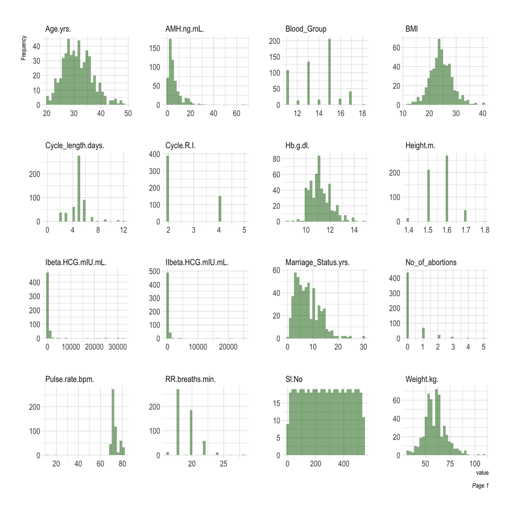

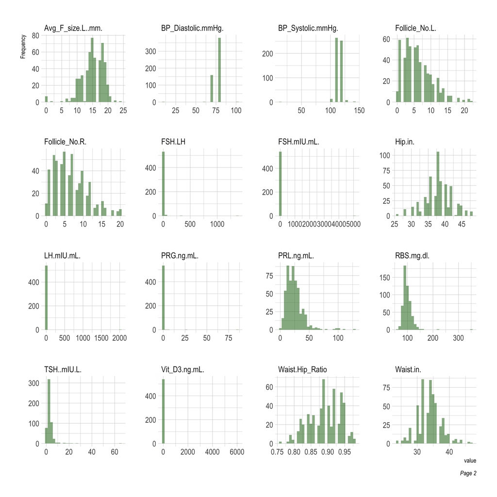

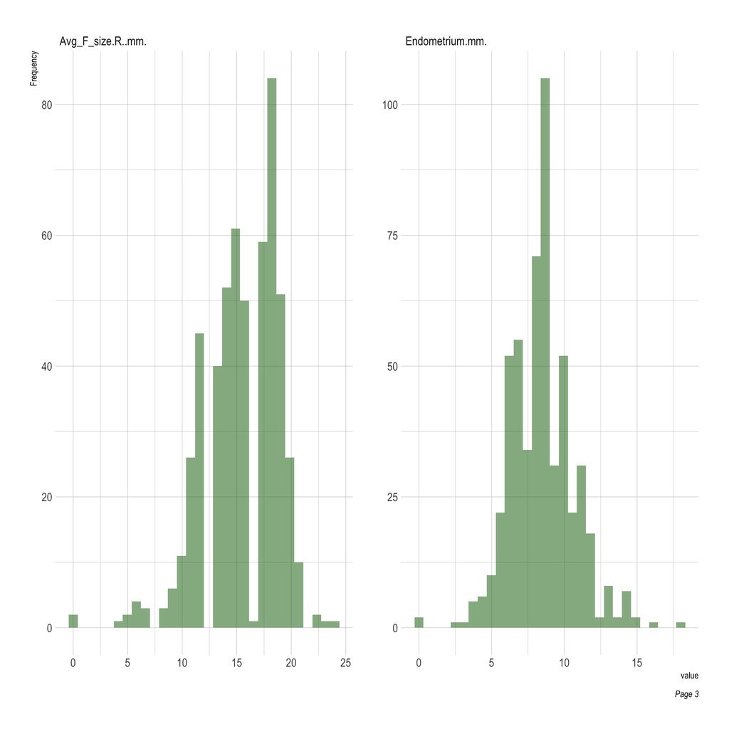

```r
colnames(pcos_data)
```

```
##  [1] "Sl.No"                "PCOS"                 "Ibeta-HCG(mIU/mL)"
##  [4] "IIbeta-HCG(mIU/mL)"   "AMH(ng/mL)"           "Age(yrs)"
##  [7] "Weight(kg)"           "Height(m)"            "BMI"
## [10] "Blood_Group"          "Pulse rate(bpm)"      "RR(breaths/min)"
## [13] "Hb(g/dl)"             "Cycle(R/I)"           "Cycle_length(days)"
## [16] "Marriage_Status(yrs)" "Pregnant"             "No_of_abortions"
## [19] "FSH(mIU/mL)"          "LH(mIU/mL)"           "FSH-LH"
## [22] "Hip(in)"              "Waist(in)"            "Waist-Hip_Ratio"
## [25] "TSH (mIU/L)"          "PRL(ng/mL)"           "Vit_D3(ng/mL)"
## [28] "PRG(ng/mL)"           "RBS(mg/dl)"           "Weight_gain"
## [31] "hair_growth"          "Skin_darkening"       "Hair_loss"
## [34] "Pimples"              "Fast_food"            "Reg_Exercise"
## [37] "BP_Systolic(mmHg)"    "BP_Diastolic(mmHg)"   "Follicle_No(L)"
## [40] "Follicle_No(R)"       "Avg_F_size(L)(mm)"    "Avg_F_size(R)(mm)"
## [43] "Endometrium(mm)"
```

```r
str(pcos_data)
```

```
## 'data.frame':    541 obs. of  43 variables:
##  $ Sl.No               : num  1 2 3 4 5 6 7 8 9 10 ...
##  $ PCOS                : num  0 0 1 0 0 0 0 0 0 0 ...
##  $ Ibeta-HCG(mIU/mL)   : num  1.99 60.8 494.08 1.99 801.45 ...
##  $ IIbeta-HCG(mIU/mL)  : num  1.99 1.99 494.08 1.99 801.45 ...
##  $ AMH(ng/mL)          : num  2.07 1.53 6.63 1.22 2.26 6.74 3.05 1.54 1 1.61 ...
##  $ Age(yrs)            : num  28 36 33 37 25 36 34 33 32 36 ...
##  $ Weight(kg)          : num  44.6 65 68.8 65 52 74.1 64 58.5 40 52 ...
##  $ Height(m)           : num  1.5 1.6 1.7 1.5 1.6 1.7 1.6 1.6 1.6 1.5 ...
##  $ BMI                 : num  19.8 25.4 23.8 28.9 20.3 25.6 25 22.9 15.6 23.1 ...
##  $ Blood_Group         : num  15 15 11 13 11 15 11 13 11 15 ...
##  $ Pulse rate(bpm)     : num  78 74 72 72 72 78 72 72 72 80 ...
##  $ RR(breaths/min)     : num  22 20 18 20 18 28 18 20 18 20 ...
##  $ Hb(g/dl)            : num  10.5 11.7 11.8 12 10 ...
##  $ Cycle(R/I)          : num  2 2 2 2 2 2 2 2 2 4 ...
```

[output cut: 29 more lines]

```r
#DataExplorer::create_report(pcos_data, output_file='pcos_data.html')
```

$~$

### Plots:

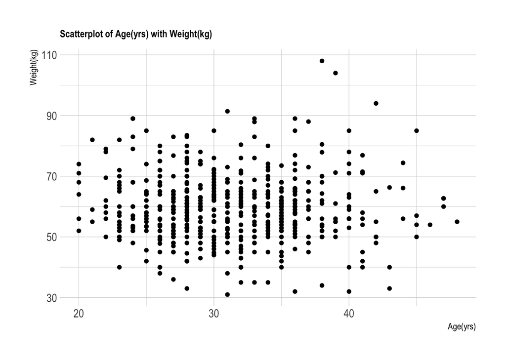

```r
ggplot(pcos_data, aes(x=pcos_data$'Age(yrs)', y=pcos_data$'Weight(kg)')) +
    geom_point() +
  labs(title="Scatterplot of Age(yrs) with Weight(kg)",
        x ="Age(yrs)", y = "Weight(kg)") +
  theme_ipsum() +
    theme(
      plot.title = element_text(size=10)
    )
```

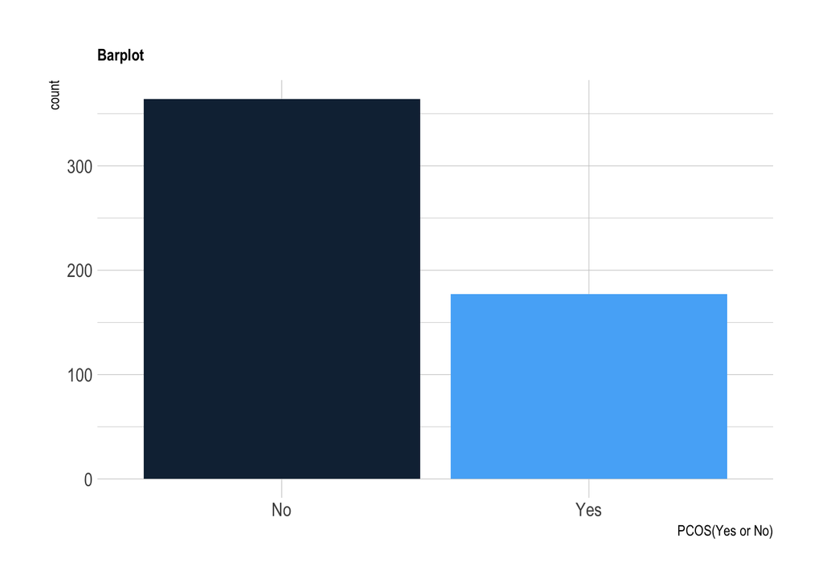

```r
pcos_data %>%
  ggplot(aes(x = as.factor(PCOS), fill = PCOS)) +
    geom_bar(show.legend = FALSE) +
  scale_x_discrete(labels=c('No', 'Yes')) +
  labs(title="Barplot",
        x ="PCOS(Yes or No)", y = "count") +
  theme_ipsum() +
    theme(
      plot.title = element_text(size=10)
    )
```

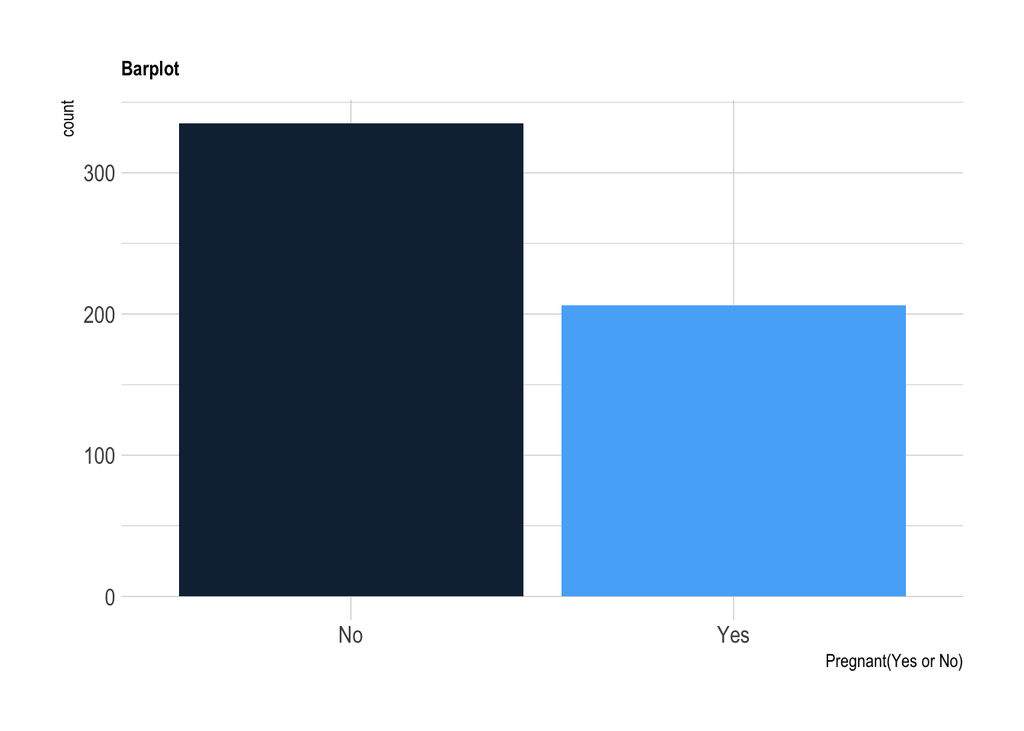

```r
pcos_data %>%
  ggplot(aes(x = as.factor(Pregnant), fill = Pregnant)) +
    geom_bar(show.legend = FALSE) +
  scale_x_discrete(labels=c('No', 'Yes')) +
  labs(title="Barplot",
        x ="Pregnant(Yes or No)", y = "count") +
  theme_ipsum() +
    theme(
      plot.title = element_text(size=10)
    )
```

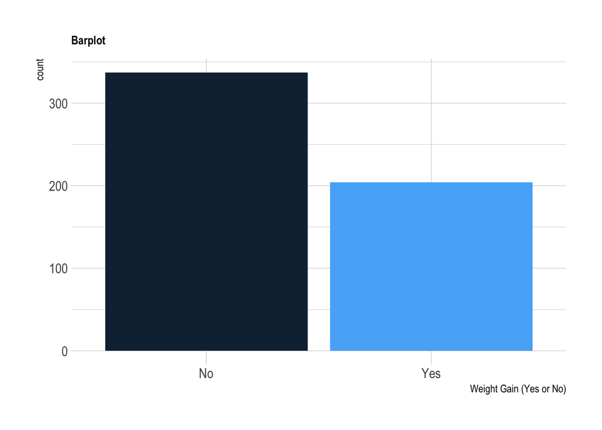

```r
pcos_data %>%
  ggplot(aes(x = as.factor(Weight_gain), fill = Weight_gain)) +
    geom_bar(show.legend = FALSE) +
  scale_x_discrete(labels=c('No', 'Yes')) +
  labs(title="Barplot",
        x ="Weight Gain (Yes or No)", y = "count") +
  theme_ipsum() +
    theme(
      plot.title = element_text(size=10)
    )
```

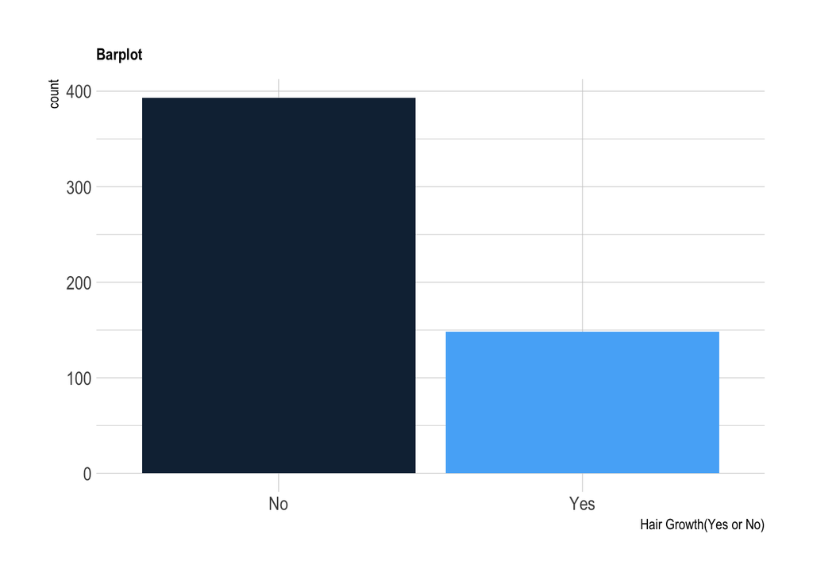

```r
pcos_data %>%
  ggplot(aes(x = as.factor(hair_growth), fill = hair_growth)) +
    geom_bar(show.legend = FALSE) +
  scale_x_discrete(labels=c('No', 'Yes')) +
  labs(title="Barplot",
        x ="Hair Growth(Yes or No)", y = "count") +
  theme_ipsum() +
    theme(
      plot.title = element_text(size=10)
    )
```

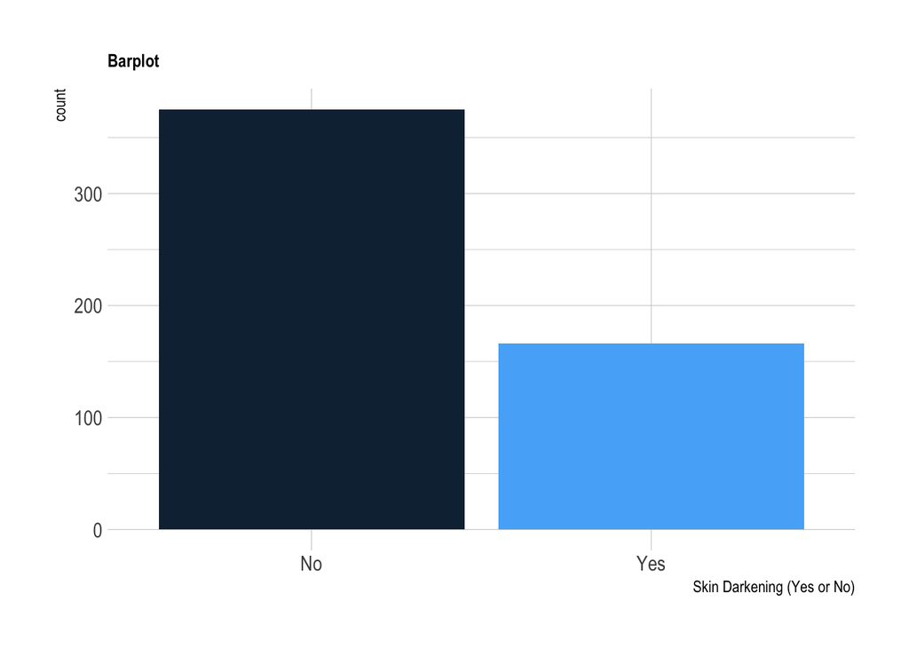

```r
pcos_data %>%
  ggplot(aes(x = as.factor(Skin_darkening), fill = Skin_darkening)) +
    geom_bar(show.legend = FALSE) +
  scale_x_discrete(labels=c('No', 'Yes')) +
  labs(title="Barplot",
        x ="Skin Darkening (Yes or No)", y = "count") +
  theme_ipsum() +
    theme(
      plot.title = element_text(size=10)
    )
```

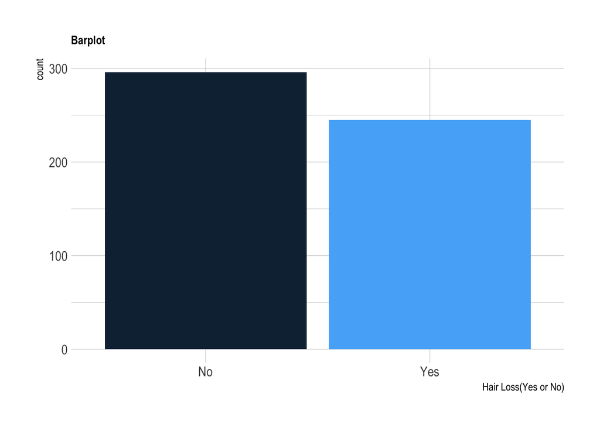

```r
pcos_data %>%
  ggplot(aes(x = as.factor(Hair_loss), fill = Hair_loss)) +
    geom_bar(show.legend = FALSE) +
  scale_x_discrete(labels=c('No', 'Yes')) +
  labs(title="Barplot",
        x ="Hair Loss(Yes or No)", y = "count") +
  theme_ipsum() +
    theme(
      plot.title = element_text(size=10)
    )
```

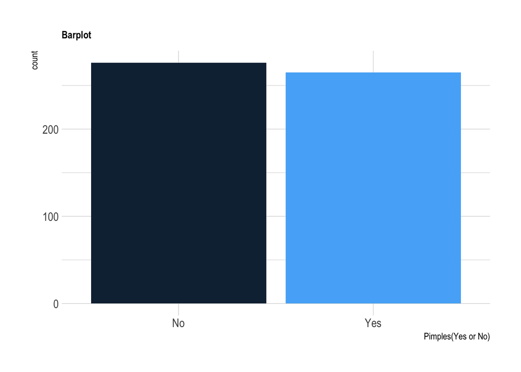

```r
pcos_data %>%
  ggplot(aes(x = as.factor(Pimples), fill = Pimples)) +
    geom_bar(show.legend = FALSE) +
  scale_x_discrete(labels=c('No', 'Yes')) +
  labs(title="Barplot",
        x ="Pimples(Yes or No)", y = "count") +
  theme_ipsum() +
    theme(
      plot.title = element_text(size=10)
    )
```

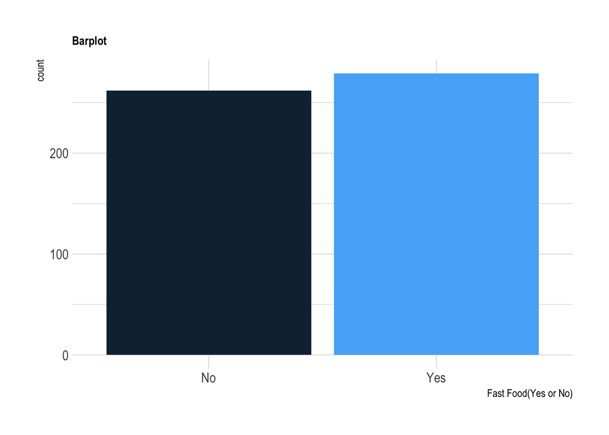

```r
pcos_data %>%
  ggplot(aes(x = as.factor(Fast_food), fill = Fast_food)) +
    geom_bar(show.legend = FALSE) +
  scale_x_discrete(labels=c('No', 'Yes')) +
  labs(title="Barplot",
        x ="Fast Food(Yes or No)", y = "count") +
  theme_ipsum() +
    theme(
      plot.title = element_text(size=10)
    )
```

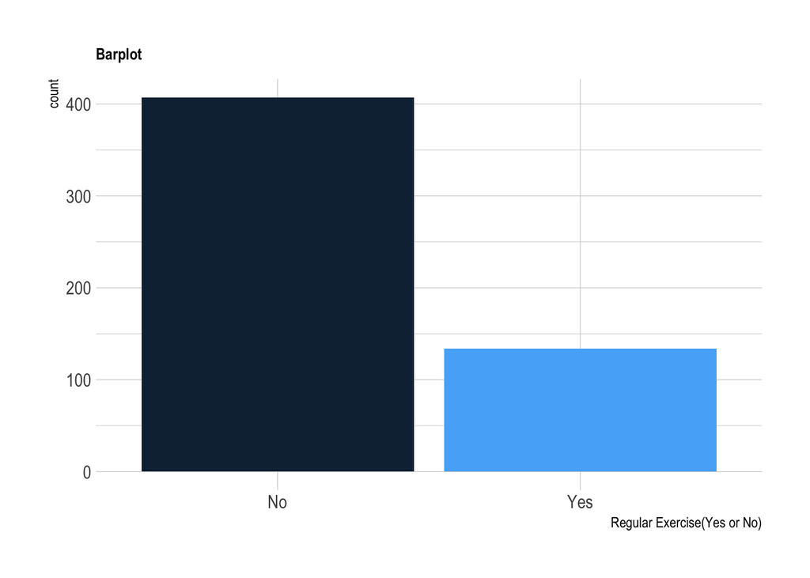

```r
pcos_data %>%
  ggplot(aes(x = as.factor(Reg_Exercise), fill = Reg_Exercise)) +
    geom_bar(show.legend = FALSE) +
  scale_x_discrete(labels=c('No', 'Yes')) +
  labs(title="Barplot",
        x ="Regular Exercise(Yes or No)", y = "count") +
  theme_ipsum() +
    theme(
      plot.title = element_text(size=10)
    )
```

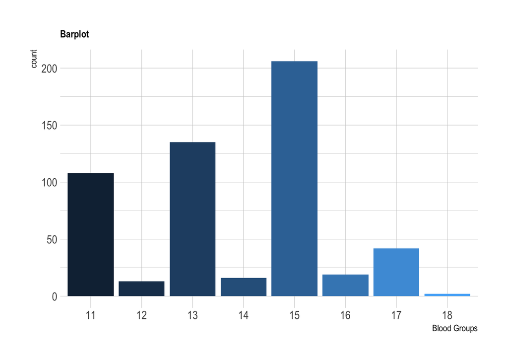

```r
pcos_data %>%
  ggplot(aes(x = as.factor(Blood_Group), fill = Blood_Group)) +
    geom_bar(show.legend = FALSE) +
  labs(title="Barplot",
        x ="Blood Groups", y = "count") +
  theme_ipsum() +
    theme(
      plot.title = element_text(size=10)
    )
```

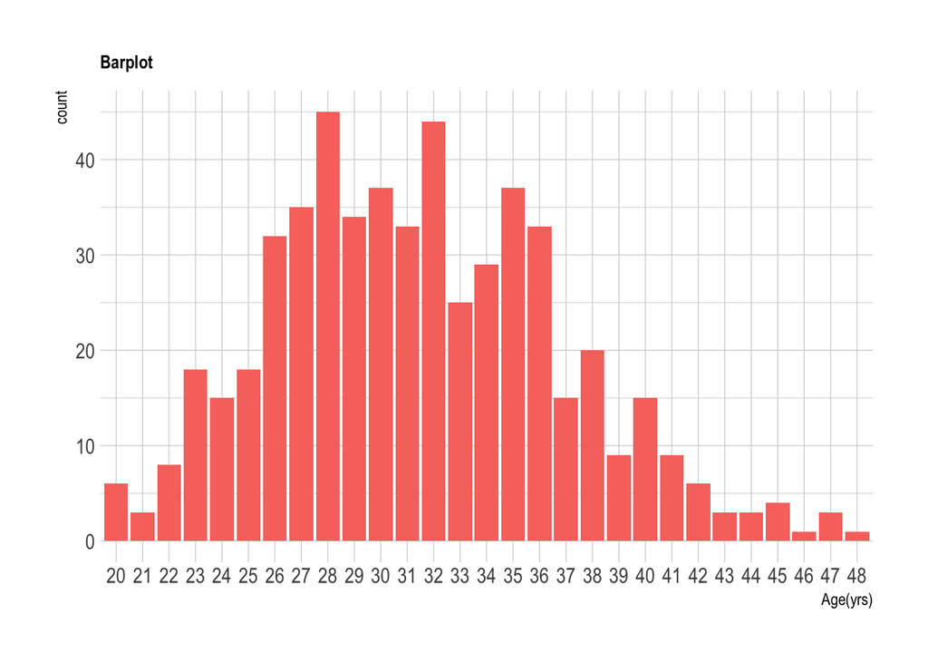

```r
pcos_data %>%
  ggplot(aes(x = as.factor(`Age(yrs)`), fill="#69b3a2")) +
    geom_histogram(stat="count", show.legend = FALSE) +
  labs(title="Barplot",
        x ="Age(yrs)", y = "count") +
  theme_ipsum() +
    theme(
      plot.title = element_text(size=10)
    )
```

[figure not shown]

```r
pcos_data %>%
  ggplot(aes(x = as.factor(`Weight(kg)`), fill="#69b3a2")) +
    geom_histogram(stat="count", show.legend = FALSE) +
  labs(title="Barplot",
        x ="Weight(kg)", y = "count") +
  theme_ipsum() +
    theme(
      plot.title = element_text(size=5)
    )
```

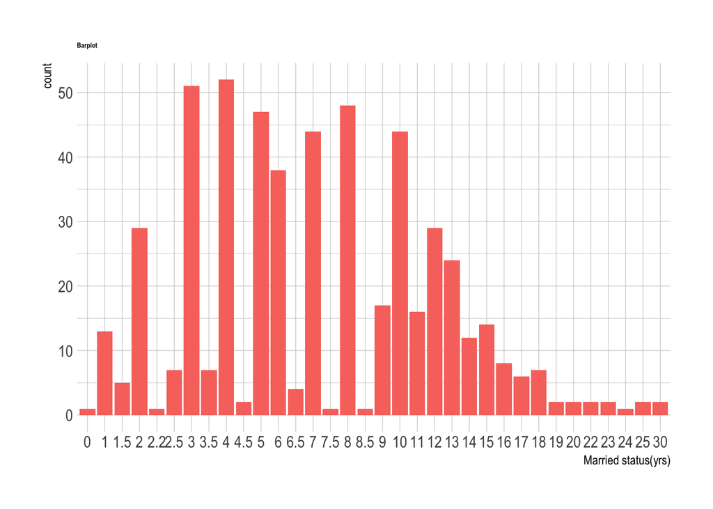

```r
pcos_data %>%
  ggplot(aes(x = as.factor(`Marriage_Status(yrs)`), fill="#69b3a2")) +
    geom_histogram(stat="count", show.legend = FALSE) +
  labs(title="Barplot",
        x ="Married status(yrs)", y = "count") +
  theme_ipsum() +
    theme(
      plot.title = element_text(size=5)
    )
```

$~$

## References:

- Kottarathil, P. (2020, October 11). Polycystic ovary syndrome (PCOS). Kaggle. Retrieved October 9, 2022, from https://www.kaggle.com/datasets/prasoonkottarathil/polycystic-ovary-syndrome-pcos
- Stewart, M. M., & Foster, S. (2012). PCOS awareness association. PCOS Awareness Association. Retrieved October 9, 2022, from https://www.pcosaa.org/
- Bartlett, E., & Erlich, L. (2015). Feed your fertility: Your guide to cultivating a healthy pregnancy with traditional Chinese medicine, real food, and holistic living. Fair Winds Press.